# Knowledge Organization 1

Author

Stan Brouwer sjbrou@gmail.com

# Assignment 1:

There are loads of tools that automate drawing mindmaps concerning certain subjects; for instance “[wikipedia-map](https://wikipedia.luk.ke/)” which creates an mindmap based on the hyperlinks it finds in the first paragraph of the wikipedia article concerning the topic.

[figure not shown]

Example wikipedia-map

We can make use of the wikipedia API to automatically scrape all links of a certain page, for instance about “Semantics” (printing the first 10 results)

```r
# Required libraries
library(httr)
library(jsonlite)
library(rvest)
library(plotly)
library(ggplot2)

# Function to get all linked articles from a Wikipedia page, excluding those with ":"
get_wikipedia_links <- function(search_term) {
  search_term <- URLencode(search_term)   # search term encoding
  api_url <- paste0("https://en.wikipedia.org/w/api.php?action=parse&page=", search_term, "&format=json&prop=text") # create URL
  response <- GET(api_url) # GET request
  if (status_code(response) != 200) {
    stop("Failed to fetch Wikipedia page")
  }
  content <- fromJSON(content(response, "text"))
  html_content <- content$parse$text$`*`
  html <- read_html(html_content)

  # Extraction of links
  links <- html %>%
    html_nodes("a") %>%
    html_attr("href")

  # Many links pointed to files or other unwanted resources. Those links contained ":" and we can filter those out
  article_links <- links[grepl("^/wiki/", links) & !grepl(":", links)]
  article_titles <- gsub("^/wiki/", "", article_links)

  return(unique(article_titles))
}

# Example:
links <- get_wikipedia_links("Semantics")
print(links[1:10])
```

```
 [1] "Semantics_(disambiguation)" "Linguistic"
 [3] "Meaning_(philosophy)"       "Sense_and_reference"
 [5] "Syntax"                     "Grammatically"
 [7] "Pragmatics"                 "Lexical_semantics"
 [9] "Word_meaning"               "Lexical_relations"
```

```r
likely_picks <- get_wikipedia_links("Time_Person_of_the_Year")
likely_picks <- likely_picks[1:50]
```

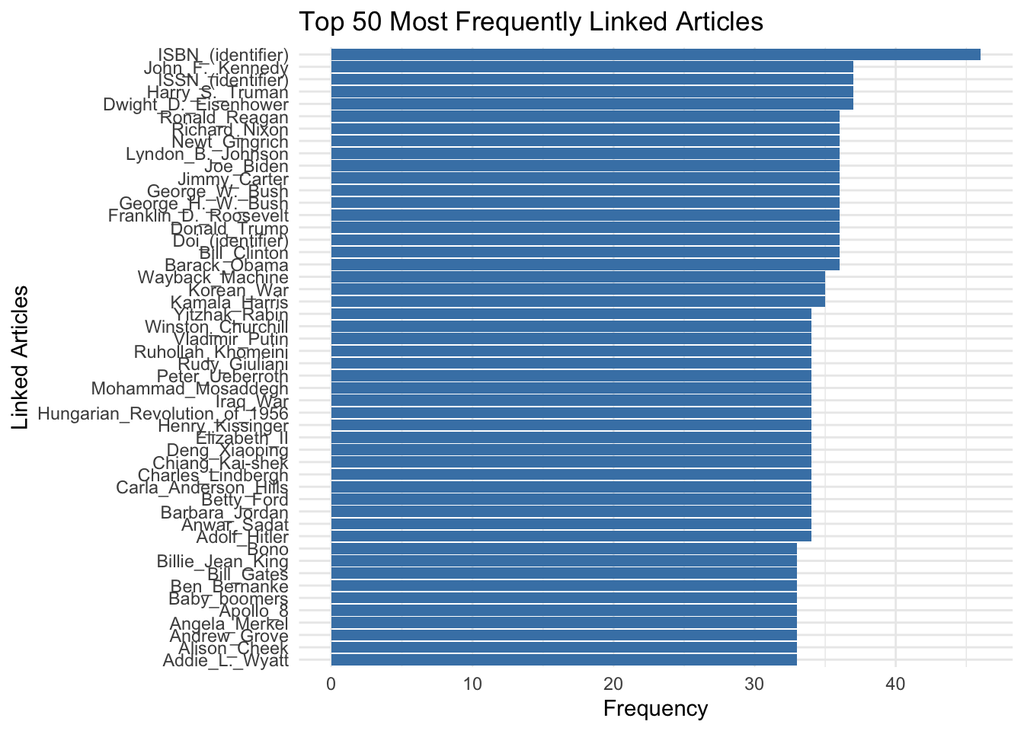

```r
get_frequencies <- function(base_term) {
  links <- get_wikipedia_links(base_term)
  first_50_links <- links[1:50]
  all_links <- c()
  for (link in first_50_links) {
    Sys.sleep(1) # API has rate limitor
    sub_links <- get_wikipedia_links(link)
    all_links <- c(all_links, sub_links)
  }
  link_frequencies <- table(all_links)
  link_frequencies <- sort(link_frequencies, decreasing = TRUE)
  return(link_frequencies)
}
plot_frequencies <- function(frequencies) {
  freq_df <- as.data.frame(frequencies)
  colnames(freq_df) <- c("Link", "Frequency")
  ggplot(freq_df[1:50, ], aes(x = reorder(Link, Frequency), y = Frequency)) +
    geom_bar(stat = "identity", fill = "steelblue") +
    coord_flip() +
    xlab("Linked Articles") +
    ylab("Frequency") +
    ggtitle("Top 50 Most Frequently Linked Articles") +
    theme_minimal()
}

link_frequencies <- get_frequencies("Time_Person_of_the_Year")
plot_frequencies(link_frequencies)
```

Unfortunately, due to the way that the nodes and links in the graph are organized, guessing the most frequent node does not necissarily lead to the optimal search strategy; but it is a good place to start.

Reading about the optimal guess-who strategy is also quite interesting:

[lancaster article](https://www.lancaster.ac.uk/stor-i-student-sites/edward-mellor/2020/02/26/optimal-strategy-for-guess-who/)

[PLOS ONE - Optimal guessing in ‘Guess Who’ - Ben O’Neil](https://www.ncbi.nlm.nih.gov/pmc/articles/PMC7946196/)